# Transport Choices in Daily Life

## What’s going on with this data?

This visual data story explores how people commute in daily life, using data collected from observations via a Google Form. The logged information includes the observed transport method, preferred transport mode, commute time, and whether the journey involved walking. This data allows us to examine not only behavior but also sentiment around transport choices.To increase the value of the data collected in Project 4, I added a new question: “If you could choose your preferred mode of transportation, what would you choose?” The goal of this was to capture people’s preferences even if their actual observed behavior didn’t match their preferences. This helped me gauge the popularity of various modes of transportation, adding additional explanatory value to the data set.All observations were made by myself and a few of my friends.

## Preferred Modes of Transport

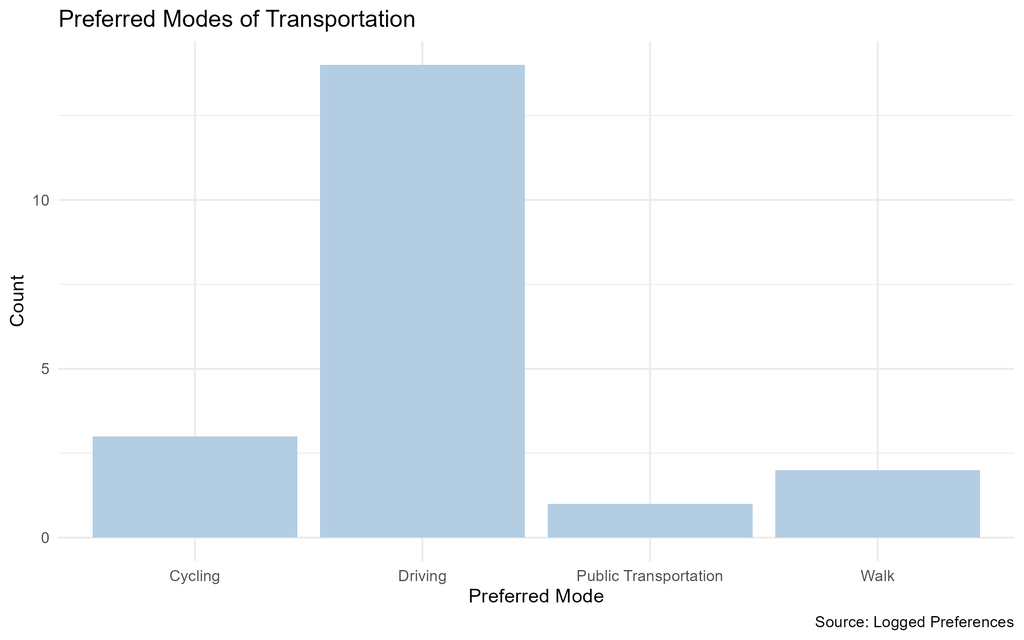

## Commute Time by Observed Transport Mode

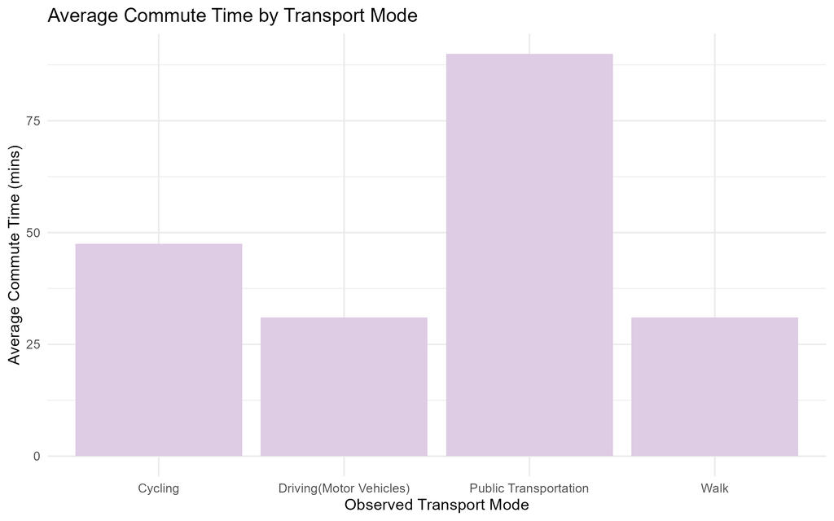

Public transportation had the longest average commute times, while driving and walking were the shortest. This may reflect delays or transfer times associated with buses or trains. Cycling also shows a moderate commute length, which could reflect its balance between speed and route flexibility.

## Proportion of Transport Modes That Include Walking

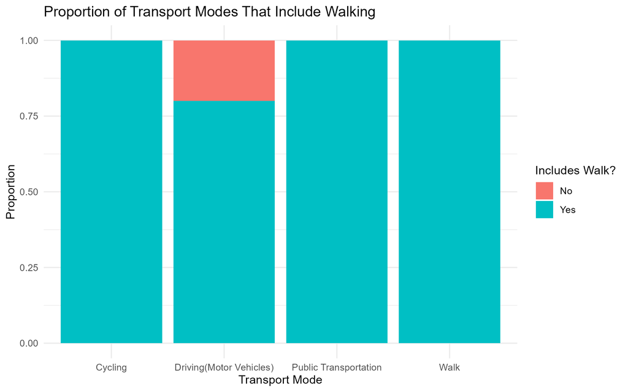

Almost all forms of commuting include some walking — even driving and public transport. However, in some driving records, walking was not observed. This plot reveals that walking remains a foundation component of most commute types.

## Final reflections

The data reveals a clear preference for driving, but also suggests that public transportation may be less time-efficient for some users. Walking is highly integrated across transport types, reinforcing its importance in urban mobility. This story highlights how preference and behavior don’t always align — and that even car users are often pedestrians too.